# Practical Machine Learning Project

KF

8/27/2020

## Executive Summary

This assignment is designed to predict the quality of barbell reps using data from accelerometers on the belt, forearm, arm, and dumbbell. The first part of this research is to explore the data and find data points that may be good predictors of exercise quality. After doing that, I will use the useful variables and fit multiple models to see which would best predict the results of an unknown “test” data set.

## Exploratory Analysis

After downloading the training data set, I reviewed the available variables so I could remove the ones that would not help predict the outcome. There were 108 out of the original 160 variables that were only descriptive but not helpful in predicting the outcome (time stamps, user names, metadata, etc.). The remaining 52 variables will be used in the models to see what is helpful in predicting Classe (outcome).

## Modeling

### Set Training and Testing Data

The first step of modeling is to split the training data into two sets. The first will be used to fit the model (70%) and the second will be used to test the models for best accuracy (30%). The “test” data provided by the assignment will only be used as a “validation” data set for the test.

### Random Forest

I fit a Random Forest model to the training data (method=“rf”). When comparing the second data set against a prediction using this model, the results gave an accuracy of 99.34%.

```
## Confusion Matrix and Statistics
##
##           Reference
## Prediction    A    B    C    D    E
##          A 1674    6    0    0    0
##          B    0 1126    5    0    0
##          C    0    7 1019   10    4
##          D    0    0    2  954    5
##          E    0    0    0    0 1073
##
## Overall Statistics
##
##                Accuracy : 0.9934
##                  95% CI : (0.991, 0.9953)
##     No Information Rate : 0.2845
##     P-Value [Acc > NIR] : < 2.2e-16
##
##                   Kappa : 0.9916
##
##  Mcnemar's Test P-Value : NA
##
## Statistics by Class:
##
##                      Class: A Class: B Class: C Class: D Class: E
## Sensitivity            1.0000   0.9886   0.9932   0.9896   0.9917
## Specificity            0.9986   0.9989   0.9957   0.9986   1.0000
## Pos Pred Value         0.9964   0.9956   0.9798   0.9927   1.0000
## Neg Pred Value         1.0000   0.9973   0.9986   0.9980   0.9981
## Prevalence             0.2845   0.1935   0.1743   0.1638   0.1839
## Detection Rate         0.2845   0.1913   0.1732   0.1621   0.1823
## Detection Prevalence   0.2855   0.1922   0.1767   0.1633   0.1823
## Balanced Accuracy      0.9993   0.9938   0.9944   0.9941   0.9958
```

### Linear Discriminant Analysis

I fit a LDA model to the training data (method=“lda”). When comparing the second data set against a prediction using this model, the results gave an accuracy of 69.6%.

```
## Confusion Matrix and Statistics
##
##           Reference
## Prediction    A    B    C    D    E
##          A 1358  178  116   58   47
##          B   37  744  101   52  199
##          C  132  139  669  115  106
##          D  140   35  121  702  107
##          E    7   43   19   37  623
##
## Overall Statistics
##
##                Accuracy : 0.696
##                  95% CI : (0.6841, 0.7077)
##     No Information Rate : 0.2845
##     P-Value [Acc > NIR] : < 2.2e-16
##
##                   Kappa : 0.6151
##
##  Mcnemar's Test P-Value : < 2.2e-16
##
## Statistics by Class:
##
##                      Class: A Class: B Class: C Class: D Class: E
## Sensitivity            0.8112   0.6532   0.6520   0.7282   0.5758
## Specificity            0.9052   0.9180   0.8987   0.9181   0.9779
## Pos Pred Value         0.7729   0.6567   0.5762   0.6353   0.8546
## Neg Pred Value         0.9234   0.9169   0.9244   0.9452   0.9110
## Prevalence             0.2845   0.1935   0.1743   0.1638   0.1839
## Detection Rate         0.2308   0.1264   0.1137   0.1193   0.1059
## Detection Prevalence   0.2986   0.1925   0.1973   0.1878   0.1239
## Balanced Accuracy      0.8582   0.7856   0.7754   0.8232   0.7769
```

### Generalized Boosted Regression

I fit a GBM model to the training data (method=“gbm”). When comparing the second data set against a prediction using this model, the results gave an accuracy of 96.21%.

```
## Confusion Matrix and Statistics
##
##           Reference
## Prediction    A    B    C    D    E
##          A 1649   26    0    2    3
##          B   17 1078   29    8    7
##          C    5   35  983   28   20
##          D    2    0   12  917   17
##          E    1    0    2    9 1035
##
## Overall Statistics
##
##                Accuracy : 0.9621
##                  95% CI : (0.9569, 0.9668)
##     No Information Rate : 0.2845
##     P-Value [Acc > NIR] : < 2.2e-16
##
##                   Kappa : 0.9521
##
##  Mcnemar's Test P-Value : 9.305e-07
##
## Statistics by Class:
##
##                      Class: A Class: B Class: C Class: D Class: E
## Sensitivity            0.9851   0.9464   0.9581   0.9512   0.9566
## Specificity            0.9926   0.9871   0.9819   0.9937   0.9975
## Pos Pred Value         0.9815   0.9464   0.9178   0.9673   0.9885
## Neg Pred Value         0.9941   0.9871   0.9911   0.9905   0.9903
## Prevalence             0.2845   0.1935   0.1743   0.1638   0.1839
## Detection Rate         0.2802   0.1832   0.1670   0.1558   0.1759
## Detection Prevalence   0.2855   0.1935   0.1820   0.1611   0.1779
## Balanced Accuracy      0.9889   0.9668   0.9700   0.9725   0.9770
```

### Model Decision and “Test” Output

Based on the accuracy of each model, the Random Forest has the highest accuracy at 99.34% and an out-of-sample error rate of 0.66% so I will use that against the test data.

```
##  [1] B A B A A E D B A A B C B A E E A B B B
## Levels: A B C D E
```

## Appendix

### Correlation Plot

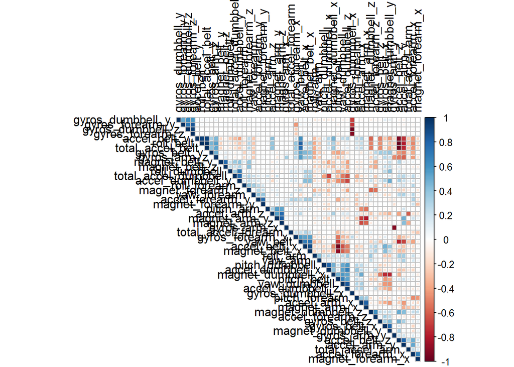

```
##  [1] "accel_belt_z"     "roll_belt"        "accel_belt_y"     "accel_dumbbell_z"
##  [5] "accel_belt_x"     "pitch_belt"       "accel_arm_x"      "accel_dumbbell_x"
##  [9] "magnet_arm_y"     "gyros_forearm_y"  "gyros_dumbbell_x" "gyros_dumbbell_z"
## [13] "gyros_arm_x"
```

### Training Data

[output not shown]

[output cut: 86 more lines]